# Multiple Linear Regression

## ASSIGNMENT 2

## First-order Model with Interaction Terms (Quantitative and Qualitative Variable and Model Selection

*Deadline: Nov 23 , 2025, by 11:59 pm. Submit to Gradescope.ca*

© Thuntida Ngamkham 2022 Modified by Danika Lipman 2024

**Problem 1**. The file **tires.csv** provides the results of an experiment on tread wear per 160 km and the driving speed in km/hour. The researchers looked at 2 types of tires and tested 20 random sample tires. The response variable is the tread wear per 160 km in the percentage of tread thickness, and the quantitative predictor is the average speed in km/hour.

```r
tires=read.csv("https://raw.githubusercontent.com/Thuntida/dataset/refs/heads/main/tires.csv", header = TRUE)
head(tires,5)
```

|  | type | wear | ave |
| --- | --- | --- | --- |
| 1 | A | 0.3 | 80 |
| 2 | A | 0.3 | 80 |
| 3 | A | 0.3 | 80 |
| 4 | A | 0.3 | 80 |
| 5 | A | 0.3 | 80 |

```r
str(tires)
```

```
'data.frame':   140 obs. of  3 variables:
 $ type: chr  "A" "A" "A" "A" ...
 $ wear: num  0.3 0.3 0.3 0.3 0.3 0.3 0.3 0.4 0.4 0.4 ...
 $ ave : int  80 80 80 80 80 80 80 88 88 88 ...
```

Answer the following questions

1. Use the individual T-test to evaluate the significant predictors from the full model at $\alpha=0.05$ and write the estimated best fit model.

```r
tires$type <- as.factor(tires$type)

full_model <- lm(wear ~ ave + type, data = tires)
summary(full_model)
```

```
Call:
lm(formula = wear ~ ave + type, data = tires)

Residuals:
      Min        1Q    Median        3Q       Max
-0.092858 -0.033451 -0.000953  0.039404  0.116668

Coefficients:
              Estimate Std. Error t value Pr(>|t|)
(Intercept) -0.6445083  0.0525675  -12.26   <2e-16 ***
ave          0.0113094  0.0005155   21.94   <2e-16 ***
typeB        0.1725006  0.0093544   18.44   <2e-16 ***
---
Signif. codes:  0 ‘***’ 0.001 ‘**’ 0.01 ‘*’ 0.05 ‘.’ 0.1 ‘ ’ 1

Residual standard error: 0.05384 on 137 degrees of freedom
Multiple R-squared:  0.8861,    Adjusted R-squared:  0.8844
F-statistic: 532.8 on 2 and 137 DF,  p-value: < 2.2e-16
```

Since both ave and typeB are significant, the best-fit additive model is: y=−0.6445+0.0113(ave)+0.1725(typeB)

2. Based on the output in (a), define the dummy variable that explains the two types of tires.

type A = 0 (baseline) For Type A tires, the model is 𝑦= − 0.6445 + 0.01131 ⋅ ave

type B = 1 For Type B tires, the model is 𝑦= − 0.6445 + 0.01131 ⋅ ave + 0.1725

3. From the best fit model in part (a), interpret all possible regression coefficient estimates,$\hat{\beta_i}$. Intercept = –0.6445 Slope for ave = 0.01131 Coefficient for type B = 0.1725

When speed = 0 km/h and tire = Type A, predicted wear is −0.6445%. While holding tire type constant, for each 1 km/h increase in speed, the tread wear increases by 0.01131 percentage points per 160 km. At the same speed, Type B tires wear 0.1725 percentage points more than Type A tires on average.

4. From the best fit model in part (a), you can improve this model by adding an interaction term(s). Evaluate whether the interaction term(s) is(are) significant to be added in the model at $\alpha = 0.05$. Summarize which model would you suggest using for predicting y.

```r
interaction_model <- lm(wear ~ ave * type, data = tires)
summary(interaction_model)
```

```
Call:
lm(formula = wear ~ ave * type, data = tires)

Residuals:
      Min        1Q    Median        3Q       Max
-0.070158 -0.016493 -0.003643  0.024086  0.063703

Coefficients:
              Estimate Std. Error t value Pr(>|t|)
(Intercept) -0.3888744  0.0347705  -11.18   <2e-16 ***
ave          0.0087833  0.0003415   25.72   <2e-16 ***
typeB       -1.0800050  0.0779442  -13.86   <2e-16 ***
ave:typeB    0.0119840  0.0007439   16.11   <2e-16 ***
---
Signif. codes:  0 ‘***’ 0.001 ‘**’ 0.01 ‘*’ 0.05 ‘.’ 0.1 ‘ ’ 1

Residual standard error: 0.03169 on 136 degrees of freedom
Multiple R-squared:  0.9608,    Adjusted R-squared:   0.96
F-statistic:  1112 on 3 and 136 DF,  p-value: < 2.2e-16
```

```r
anova(full_model, interaction_model)
```

```
Analysis of Variance Table

Model 1: wear ~ ave + type
Model 2: wear ~ ave * type
  Res.Df     RSS Df Sum of Sq      F    Pr(>F)
1    137 0.39710
2    136 0.13655  1   0.26056 259.52 < 2.2e-16 ***
---
Signif. codes:  0 ‘***’ 0.001 ‘**’ 0.01 ‘*’ 0.05 ‘.’ 0.1 ‘ ’ 1
```

The interaction model reduces RSS by 0.26056, and the improvement is also statistically significant (p < 0.05). So the interaction term is significant at alpha = 0.05. The interaction model is better than the additive model. The recommended model is: wear = - 0.3889+ 0.008783(ave) - 1.0800(typeB) + 0.011984(ave x typeB)

5. From the model in part (d), report the adjusted-$R^2$ value from the model selected and interpret its value. Adjusted R-squared: 0.960 The model explains 96.0% of the variation in tread wear after adjusting for the number of predictors. This shows a good fit, meaning speed, tire type, and their interaction account for nearly all observed variation in wear.
6. Predict the average tread wear per 160 km in the percentage of tread thickness for a car with type A with the average speed of 100 km/hour from the model selected in part (d) with 95% confidence.

```r
new <- data.frame(type = "A", ave = 100)
predict(interaction_model, newdata = new, interval = "confidence", level = 0.95)
```

```
      fit       lwr       upr
1 0.48946 0.4819268 0.4969932
```

We are 95% confident that the average tread wear per 160 km for Type A tires driven at 100 km/h lies between 0.482% and 0.497%.

**Problem 2**. A team of mental health researchers wishes to compare three methods (A, B, and C) of treating severe depression. They would also like to study the relationship between age and treatment effectiveness as well as the interaction (if any) between age and treatment.

Each member of a simple random sample of 36 patients, comparable with respect to diagnosis and severity of depression, was randomly assigned to receive treatment A, B, or C. The data are given in **MentalHealth.csv**.

```r
mentalhealth=read.csv("https://raw.githubusercontent.com/Thuntida/dataset/refs/heads/main/MentalHealth.csv", header = TRUE)
head(mentalhealth,5)
```

|  | EFFECT | AGE | METHOD |
| --- | --- | --- | --- |
| 1 | 56 | 21 | A |
| 2 | 41 | 23 | B |
| 3 | 40 | 30 | B |
| 4 | 28 | 19 | C |
| 5 | 55 | 28 | A |

Answer the following questions

1. Which is the dependent variable (the response variable)?

Effect is the dependent variable.

2. What are the independent variables (the predictors)? Age and Method are the independent variable.
3. Draw a scatter diagram of the sample data with EFFECT on the y-axis and AGE on the x-axis using different symbols/colors for each of the three treatments. Briefly summarize the visualization. [Hint: Check MLR part II under Interaction Effect in MLR with both Quantitative and Qualitative Variable models].

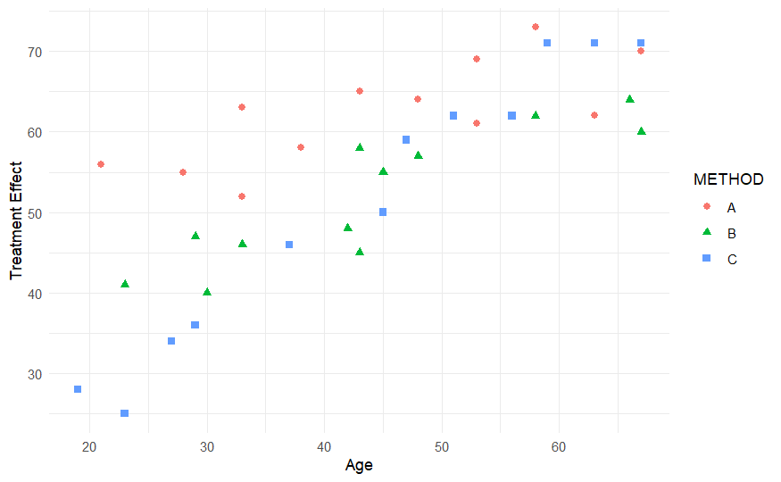

4. Is there any interaction between age and treatment? Test the hypothesis at $\alpha=0.05$. Null hypothesis: No interaction between AGE and METHOD.

```r
int_model <- lm(EFFECT ~ AGE * METHOD, data = mentalhealth)
summary(int_model)
```

```
Call:
lm(formula = EFFECT ~ AGE * METHOD, data = mentalhealth)

Residuals:
    Min      1Q  Median      3Q     Max
-6.4366 -2.7637  0.1887  2.9075  6.5634

Coefficients:
             Estimate Std. Error t value Pr(>|t|)
(Intercept)  47.51559    3.82523  12.422 2.34e-13 ***
AGE           0.33051    0.08149   4.056 0.000328 ***
METHODB     -18.59739    5.41573  -3.434 0.001759 **
METHODC     -41.30421    5.08453  -8.124 4.56e-09 ***
AGE:METHODB   0.19318    0.11660   1.657 0.108001
AGE:METHODC   0.70288    0.10896   6.451 3.98e-07 ***
---
Signif. codes:  0 ‘***’ 0.001 ‘**’ 0.01 ‘*’ 0.05 ‘.’ 0.1 ‘ ’ 1

Residual standard error: 3.925 on 30 degrees of freedom
Multiple R-squared:  0.9143,    Adjusted R-squared:  0.9001
F-statistic: 64.04 on 5 and 30 DF,  p-value: 4.264e-15
```

```r
anova(int_model)
```

```
Analysis of Variance Table

Response: EFFECT
           Df Sum Sq Mean Sq F value    Pr(>F)
AGE         1 3424.4  3424.4 222.295 2.059e-15 ***
METHOD      2  805.0   402.5  26.128 2.687e-07 ***
AGE:METHOD  2  703.4   351.7  22.831 9.410e-07 ***
Residuals  30  462.1    15.4
---
Signif. codes:  0 ‘***’ 0.001 ‘**’ 0.01 ‘*’ 0.05 ‘.’ 0.1 ‘ ’ 1
```

The p-value is 9.41e-07 for the interaction between age and treatment method which is less than 0.05 (alpha). We conclude that there is a significant interaction between age and treatment method. This means the relationship between age and treatment effectiveness depends on which treatment is used.

AGE × METHODB p = 0.108 → not significant AGE × METHODC p = 3.98e-07 → significant Only Method C shows a significant interaction with age. The relationship between age and effectiveness depends on whether Method C is used.

5. From part (d), write the final model with sub-models for predicting the treatment effectiveness. Please ensure you substitute all regression coefficients to the models. EFFECT=47.5156+0.3305(AGE)−18.5974(METHODB)−41.3042(METHODC)+0.7029(AGE×METHODC)

Method A (baseline): EFFECTA = 47.5156+0.3305(AGE) Method B: EFFECTB = 28.9182 + 0.3305 ⋅ AGE(no significant interaction) Method C: EFFECTC = 6.2114+1.0334⋅AGE(significant interaction)

7. Plot the three regression lines on the scatter diagram obtained in part (c). May one have the same conclusion as in part (f)?

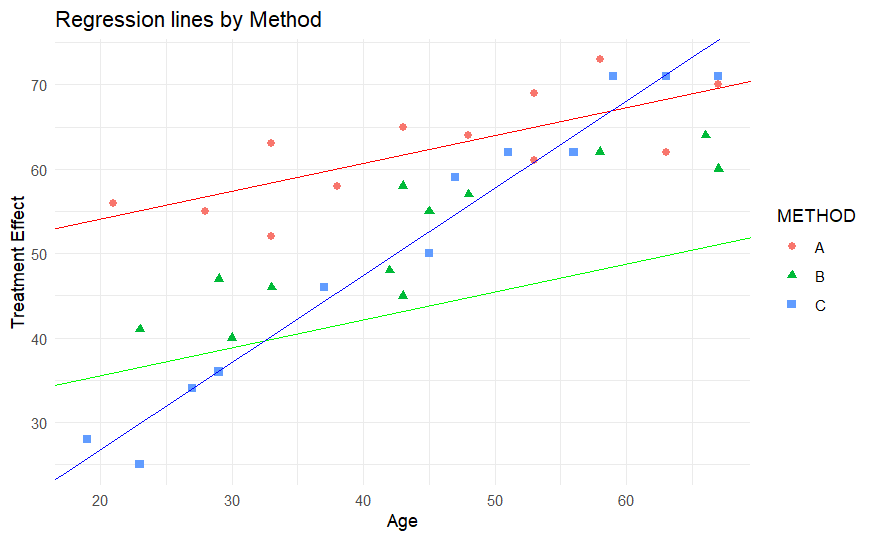

```r
ggplot(mentalhealth, aes(x = AGE, y = EFFECT, color = METHOD, shape = METHOD)) +
  geom_point(size = 2) +
  geom_abline(intercept = 47.5156, slope = 0.3305, color = "red") +   # Method A
  geom_abline(intercept = 28.9182, slope = 0.3305, color = "green") +  # Method B
  geom_abline(intercept = 6.2114, slope = 1.0334, color = "blue") +  # Method C
  theme_minimal() +
  labs(x = "Age", y = "Treatment Effect", title = "Regression lines by Method")
```

**Problem 3**. **Collusive bidding in road construction**. Road construction contracts in the state of Florida are awarded on the basis of competitive, sealed bids; the contractor who submits the lowest bid price wins the contract. During the 1980s, the Office of the Florida Attorney General (FLAG) suspected numerous contractors of practicing bid collusion (i.e., setting the winning bid price above the fair, or competitive, price in order to increase proect margin). By comparing the bid prices (and other important bid variables) of the fixed (or rigged) contracts to the competitively bid contracts, FLAG was able to establish invaluable benchmarks for detecting future bid-rigging. FLAG collected data for 279 road construction contracts. For each contract, the following variables shown below were measured and are **only** considered for this problem.

1. Price of contract ($) bid by lowest bidder, LOWBID.
2. Department of Transportation (DOT) engineer’s estimate of fair contract price ($), DOTEST.
3. Status of contract (1 if fixed, 0 if competitive), STATUS
4. District (1, 2, 3, 4, or 5) in which the construction project is located, DISTRICT.
5. Number of bidders on contract, NUMIDS.
6. Estimated number of days to complete work, DAYSEST.
7. Length of road project (miles), RDLNGTH.
8. Percentage of costs allocated to liquid asphalt, PCTASPH.
9. Percentage of costs allocated to base material, PCTBASE.
10. Percentage of costs allocated to excavation, PCTEXCAV.
11. Percentage of costs allocated to mobilization, PCTMOBIL.
12. Percentage of costs allocated to structures, PCTSTRUC.
13. Percentage of costs allocated to traffic control, PCTTRAF.

The data are saved in the file named **FLAG2.txt**.

```r
flag=read.table("https://raw.githubusercontent.com/Thuntida/dataset/refs/heads/main/FLAG2.txt", header = TRUE)
head(flag,3)
```

|  | LOWBID | DOTEST | LBERATIO | STATUS | DISTRICT | NUMIDS | DAYSEST | RDLNGTH | PCTASPH | PCTBASE | PCTEXCAV | PCTMOBIL | PCTSTRUC | PCTTRAF | SUBCONT |
| --- | --- | --- | --- | --- | --- | --- | --- | --- | --- | --- | --- | --- | --- | --- | --- |
| 1 | 362916 | 385963 | 0.94029 | 0 | 1 | 3 | 100 | 7.200 | 0.626369 | 0.000000 | 0.091475 | 0.019977 | 0.116770 | 0.09170 | 0 |
| 2 | 152056 | 175396 | 0.86693 | 1 | 1 | 3 | 75 | 0.000 | 0.153284 | 0.012364 | 0.142221 | 0.047351 | 0.018020 | 0.14764 | 0 |
| 3 | 239665 | 194650 | 1.23126 | 1 | 1 | 3 | 65 | 0.206 | 0.082670 | 0.000000 | 0.105314 | 0.049235 | 0.222602 | 0.06029 | 0 |

Note: In our dataset, the variable DISTRICT represents five different regions, coded as 1–5. Before running stepwise regression, we must ensure that R treats DISTRICT as a categorical (factor) variable rather than as a numeric one.

However, when using the olsrr package, including factor(DISTRICT) directly in the model formula can cause errors or unexpected behavior. Instead, convert the variable to a factor before fitting the model:

```r
flag$DISTRICT <- as.factor(flag$DISTRICT)
str(flag$DISTRICT)
```

```
 Factor w/ 5 levels "1","2","3","4",..: 1 1 1 1 1 1 5 5 1 5 ...
```

This tells R that DISTRICT is categorical and allows it to correctly create dummy variables for each district level. As a result, the stepwise, forward, or backward selection procedures in olsrr will properly include or exclude the categorical variable in the model.

Answer the following questions:

1. Consider building a model for the low-bid price (Y). Apply **Stepwise Regression Procedure with p_enter=0.05 and p_remove=0.1** to the data to find the independent variables most suitable for modeling $Y$.

```r
# Full model
fullmodel <- lm(LOWBID ~ DOTEST + STATUS + DISTRICT + NUMIDS + DAYSEST + RDLNGTH + PCTASPH + PCTBASE + PCTEXCAV + PCTMOBIL + PCTSTRUC + PCTTRAF, data=flag)

# Stepwise selection with p_enter=0.05 and p_remove=0.1
stepwise_model <- ols_step_both_p(fullmodel, penter=0.05, premove=0.1)
stepwise_model
```

```
                               Stepwise Summary
-----------------------------------------------------------------------------
Step    Variable         AIC         SBC         SBIC        R2       Adj. R2
-----------------------------------------------------------------------------
 0      Base Model     8839.080    8846.342    8043.451    0.00000    0.00000
 1      DOTEST (+)     7812.664    7823.558    7020.607    0.97493    0.97484
 2      STATUS (+)     7802.016    7816.541    7010.086    0.97604    0.97587
 3      NUMIDS (+)     7799.830    7817.986    7007.965    0.97640    0.97614
 4      DAYSEST (+)    7798.787    7820.575    7007.007    0.97665    0.97631
-----------------------------------------------------------------------------

Final Model Output
------------------

                               Model Summary
----------------------------------------------------------------------------
R                            0.988       RMSE                    278139.328
R-Squared                    0.977       MSE                77361485590.048
Adj. R-Squared               0.976       Coef. Var                   24.532
Pred R-Squared               0.974       AIC                       7798.787
MAE                     135206.905       SBC                       7820.575
----------------------------------------------------------------------------
 RMSE: Root Mean Square Error
 MSE: Mean Square Error
 MAE: Mean Absolute Error
 AIC: Akaike Information Criteria
 SBC: Schwarz Bayesian Criteria

                                     ANOVA
-------------------------------------------------------------------------------
                    Sum of
                   Squares         DF        Mean Square       F          Sig.
-------------------------------------------------------------------------------
Regression    9.029284e+14          4       2.257321e+14    2865.595    0.0000
Residual      2.158385e+13        274    78773191531.472
Total         9.245122e+14        278
-------------------------------------------------------------------------------

                                        Parameter Estimates
----------------------------------------------------------------------------------------------------
      model          Beta    Std. Error    Std. Beta      t        Sig          lower         upper
----------------------------------------------------------------------------------------------------
(Intercept)     23805.100     49534.453                  0.481    0.631    -73711.379    121321.578
     DOTEST         0.917         0.015        0.978    61.763    0.000         0.888         0.947
     STATUS    100208.459     41905.381        0.025     2.391    0.017     17711.027    182705.890
     NUMIDS    -15390.327      7502.950       -0.023    -2.051    0.041    -30161.081      -619.572
    DAYSEST       272.268       157.074        0.027     1.733    0.084       -36.958       581.494
----------------------------------------------------------------------------------------------------
```

Stepwise regression selected DOTEST, STATUS, NUMIDS, and DAYSEST as predictors

Stepwise model equation (additive): LOWBID = 23805.10 + 0.917 x DOTEST + 100208.46 x STATUS − 15390.33 x NUMIDS + 272.27 x DAYSEST

2. Consider building a model for the low-bid price (Y). Apply **Forward Regression Procedure with p_val=0.05** :*ols_step_forward_p(fullmodel,p_val=0.05)* to the data to find the independent variables most suitable for modeling Y.

```r
forward_model <- ols_step_forward_p(fullmodel, p_val = 0.05)
forward_model
```

```
                               Stepwise Summary
----------------------------------------------------------------------------
Step    Variable        AIC         SBC         SBIC        R2       Adj. R2
----------------------------------------------------------------------------
 0      Base Model    8839.080    8846.342    8043.451    0.00000    0.00000
 1      DOTEST        7812.664    7823.558    7020.607    0.97493    0.97484
 2      STATUS        7802.016    7816.541    7010.086    0.97604    0.97587
 3      NUMIDS        7799.830    7817.986    7007.965    0.97640    0.97614
----------------------------------------------------------------------------

Final Model Output
------------------

                               Model Summary
----------------------------------------------------------------------------
R                            0.988       RMSE                    279660.155
R-Squared                    0.976       MSE                78209802418.748
Adj. R-Squared               0.976       Coef. Var                   24.621
Pred R-Squared               0.974       AIC                       7799.830
MAE                     137748.048       SBC                       7817.986
----------------------------------------------------------------------------
 RMSE: Root Mean Square Error
 MSE: Mean Square Error
 MAE: Mean Absolute Error
 AIC: Akaike Information Criteria
 SBC: Schwarz Bayesian Criteria

                                     ANOVA
-------------------------------------------------------------------------------
                    Sum of
                   Squares         DF        Mean Square       F          Sig.
-------------------------------------------------------------------------------
Regression    9.026917e+14          3       3.008972e+14     3792.15    0.0000
Residual      2.182053e+13        275    79347399544.838
Total         9.245122e+14        278
-------------------------------------------------------------------------------

                                         Parameter Estimates
-----------------------------------------------------------------------------------------------------
      model          Beta    Std. Error    Std. Beta       t        Sig          lower         upper
-----------------------------------------------------------------------------------------------------
(Intercept)     57105.973     45823.264                   1.246    0.214    -33102.981    147314.927
     DOTEST         0.937         0.009        1.000    101.011    0.000         0.919         0.956
     STATUS     95252.389     41959.825        0.024      2.270    0.024     12649.108    177855.670
     NUMIDS    -15353.820      7530.216       -0.023     -2.039    0.042    -30178.014      -529.626
-----------------------------------------------------------------------------------------------------
```

This model selected DOTEST, STATUS, and NUMIDS as predictors

Forward Selection Model (Additive): LOWBID = 57105.97 + 0.937 x DOTEST + 95252.39 x STATUS − 15353.82 x NUMIDS

3. Consider building a model for the low-bid price (Y). Apply **Backward Regression Procedure with p_val=0.05** :*ols_step_backward_p(fullmodel,p_val=0.05)* to the data to find the independent variables most suitable for modeling Y.

```r
backward_model <- ols_step_backward_p(fullmodel, p_val = 0.05)
backward_model
```

```
                               Stepwise Summary
----------------------------------------------------------------------------
Step    Variable        AIC         SBC         SBIC        R2       Adj. R2
----------------------------------------------------------------------------
 0      Full Model    7803.964    7865.695    7007.771    0.97802    0.97677
 1      DAYSEST       7802.164    7860.263    7005.831    0.97800    0.97684
 2      PCTTRAF       7800.671    7855.139    7004.176    0.97796    0.97688
 3      PCTSTRUC      7800.115    7850.952    7003.395    0.97785    0.97685
 4      RDLNGTH       7799.502    7846.708    7002.584    0.97774    0.97682
 5      PCTMOBIL      7798.804    7842.379    7001.715    0.97764    0.97680
 6      DISTRICT      7798.348    7827.397    7006.786    0.97702    0.97652
 7      PCTBASE       7798.197    7823.616    7006.526    0.97687    0.97645
 8      PCTEXCAV      7799.128    7820.916    7007.336    0.97663    0.97628
 9      PCTASPH       7799.830    7817.986    7007.965    0.97640    0.97614
----------------------------------------------------------------------------

Final Model Output
------------------

                               Model Summary
----------------------------------------------------------------------------
R                            0.988       RMSE                    279660.155
R-Squared                    0.976       MSE                78209802418.748
Adj. R-Squared               0.976       Coef. Var                   24.621
Pred R-Squared               0.974       AIC                       7799.830
MAE                     137748.048       SBC                       7817.986
----------------------------------------------------------------------------
 RMSE: Root Mean Square Error
 MSE: Mean Square Error
 MAE: Mean Absolute Error
 AIC: Akaike Information Criteria
 SBC: Schwarz Bayesian Criteria

                                     ANOVA
-------------------------------------------------------------------------------
                    Sum of
                   Squares         DF        Mean Square       F          Sig.
-------------------------------------------------------------------------------
Regression    9.026917e+14          3       3.008972e+14     3792.15    0.0000
Residual      2.182053e+13        275    79347399544.838
Total         9.245122e+14        278
-------------------------------------------------------------------------------

                                         Parameter Estimates
-----------------------------------------------------------------------------------------------------
      model          Beta    Std. Error    Std. Beta       t        Sig          lower         upper
-----------------------------------------------------------------------------------------------------
(Intercept)     57105.973     45823.264                   1.246    0.214    -33102.981    147314.927
     DOTEST         0.937         0.009        1.000    101.011    0.000         0.919         0.956
     STATUS     95252.389     41959.825        0.024      2.270    0.024     12649.108    177855.670
     NUMIDS    -15353.820      7530.216       -0.023     -2.039    0.042    -30178.014      -529.626
-----------------------------------------------------------------------------------------------------
```

This model selected DOTEST, STATUS, and NUMIDS as predictors

Final Backward Elimination Model (Additive): LOWBID = 57105.97 + 0.937 x DOTEST + 95252.39 x STATUS − 15353.82 x NUMIDS

4. Test the individual t-test at $\alpha=0.05$ to evaluate the variables in the full model. What predictors should be kept in the model based on the individual t-tests from the full model?

```r
summary(fullmodel)
```

```
Call:
lm(formula = LOWBID ~ DOTEST + STATUS + DISTRICT + NUMIDS + DAYSEST +
    RDLNGTH + PCTASPH + PCTBASE + PCTEXCAV + PCTMOBIL + PCTSTRUC +
    PCTTRAF, data = flag)

Residuals:
     Min       1Q   Median       3Q      Max
-2061552   -76832     3703    68246  1592629

Coefficients:
              Estimate Std. Error t value Pr(>|t|)
(Intercept)  7.623e+04  6.916e+04   1.102   0.2714
DOTEST       9.362e-01  1.687e-02  55.494   <2e-16 ***
STATUS       1.089e+05  4.263e+04   2.554   0.0112 *
DISTRICT2    7.773e+04  6.388e+04   1.217   0.2248
DISTRICT3    2.960e+04  2.042e+05   0.145   0.8849
DISTRICT4   -2.729e+05  1.377e+05  -1.982   0.0485 *
DISTRICT5   -2.420e+04  3.799e+04  -0.637   0.5248
NUMIDS      -2.243e+04  8.797e+03  -2.550   0.0114 *
DAYSEST      8.030e+01  1.848e+02   0.434   0.6643
RDLNGTH      5.669e+03  4.926e+03   1.151   0.2509
PCTASPH     -1.022e+05  7.985e+04  -1.281   0.2015
PCTBASE      2.516e+05  1.840e+05   1.367   0.1727
PCTEXCAV    -2.824e+05  1.610e+05  -1.754   0.0805 .
PCTMOBIL     3.322e+05  2.765e+05   1.201   0.2308
PCTSTRUC     1.459e+05  1.621e+05   0.900   0.3690
PCTTRAF     -1.002e+05  1.416e+05  -0.707   0.4800
---
Signif. codes:  0 ‘***’ 0.001 ‘**’ 0.01 ‘*’ 0.05 ‘.’ 0.1 ‘ ’ 1

Residual standard error: 278000 on 263 degrees of freedom
Multiple R-squared:  0.978, Adjusted R-squared:  0.9768
F-statistic: 780.2 on 15 and 263 DF,  p-value: < 2.2e-16
```

Predictors to keep in the model are DOTEST, STATUS, NUMIDS, and DISTRICT4; as they are significant (p < 0.05).

5. Compare the results, parts (a)-(d). Which independent variables consistently are selected as the ‘’best’’ predictors for the model? Write all possible additive model(s) for predicting $Y$. Note! Proposing more than one model is acceptable.

Variables consistently selected across stepwise, forward, backward, and t-tests: DOTEST, STATUS, and NUMIDS. Additive Model: LOWBID = 57105.97 + 0.937 x DOTEST + 95252.39 x STATUS − 15353.82 x NUMIDS

Another model can be: LOWBID = 57105.97 + 0.937 x DOTEST + 95252.39 x STATUS − 15353.82 x NUMIDS − 272900 x DISTRICT4

6. Assume that your model selected in part (e) contains the following predictors: DOTEST,STATUS,NUMBIDS, and DISTRICT. Calculate the absolute difference in average contact bid price (by the lowest bidder) between District 1 and 4,when other predictors are held as a constant. Sub-Model: LOWBID = 57105.97 + 0.937 x DOTEST + 95252.39 x STATUS − 15353.82 x NUMIDS − DISTRICT coefficients

```r
# Fitted model
best_model <- lm(LOWBID ~ DOTEST + STATUS + NUMIDS + DISTRICT, data = flag)

# Absolute difference between District 1 and 4
abs_diff_1_4 <- abs(coef(best_model)["DISTRICT4"])
abs_diff_1_4
```

```
DISTRICT4
 316505.6
```

Absolute difference = 316505.6

7. Assume that your model selected in part (e) contains the following predictors: DOTEST,STATUS,NUMBIDS, and DISTRICT. Calculate the difference in average contact bid price (by the lowest bidder) between District 2 and 5,when other predictors are held as a constant.

```r
# Absolute difference between District 2 and 5
abs_diff_2_5 <- abs(coef(best_model)["DISTRICT2"] - coef(best_model)["DISTRICT5"])
abs_diff_2_5
```

```
DISTRICT2
 85148.63
```

Absolute difference: 85148.63

8. Assume that your model selected in part (e) contains the following predictors: DOTEST,STATUS,NUMBIDS, and DISTRICT. Build the first order model with interaction terms. Write the best fit model for predicting $Y$.

```r
# Full first-order model
interaction_model <- lm(LOWBID ~ (DOTEST + STATUS + NUMIDS + DISTRICT)^2, data = flag)
summary(interaction_model)
```

```
Call:
lm(formula = LOWBID ~ (DOTEST + STATUS + NUMIDS + DISTRICT)^2,
    data = flag)

Residuals:
     Min       1Q   Median       3Q      Max
-1486446   -52732     9513    46452  1477972

Coefficients: (4 not defined because of singularities)
                   Estimate Std. Error t value Pr(>|t|)
(Intercept)      -3.353e+04  7.480e+04  -0.448  0.65434
DOTEST            1.097e+00  2.969e-02  36.955  < 2e-16 ***
STATUS           -1.199e+04  1.102e+05  -0.109  0.91342
NUMIDS           -4.697e+03  1.273e+04  -0.369  0.71248
DISTRICT2        -1.215e+04  1.653e+05  -0.073  0.94147
DISTRICT3         9.037e+04  3.802e+05   0.238  0.81229
DISTRICT4        -1.532e+06  6.568e+05  -2.332  0.02046 *
DISTRICT5        -4.438e+04  9.666e+04  -0.459  0.64655
DOTEST:STATUS     9.451e-02  3.673e-02   2.573  0.01063 *
DOTEST:NUMIDS    -1.934e-02  3.603e-03  -5.367 1.77e-07 ***
DOTEST:DISTRICT2  3.988e-02  5.577e-02   0.715  0.47518
DOTEST:DISTRICT3 -1.655e-01  5.168e-01  -0.320  0.74904
DOTEST:DISTRICT4 -2.533e-02  6.268e-02  -0.404  0.68653
DOTEST:DISTRICT5 -1.330e-01  2.870e-02  -4.636 5.64e-06 ***
STATUS:NUMIDS     1.043e+04  3.188e+04   0.327  0.74370
STATUS:DISTRICT2         NA         NA      NA       NA
STATUS:DISTRICT3         NA         NA      NA       NA
STATUS:DISTRICT4         NA         NA      NA       NA
STATUS:DISTRICT5  7.549e+04  7.891e+04   0.957  0.33964
NUMIDS:DISTRICT2  6.114e+03  2.166e+04   0.282  0.77793
NUMIDS:DISTRICT3         NA         NA      NA       NA
NUMIDS:DISTRICT4  1.519e+05  4.661e+04   3.260  0.00126 **
NUMIDS:DISTRICT5  2.525e+04  1.798e+04   1.404  0.16148
---
Signif. codes:  0 ‘***’ 0.001 ‘**’ 0.01 ‘*’ 0.05 ‘.’ 0.1 ‘ ’ 1

Residual standard error: 251800 on 260 degrees of freedom
Multiple R-squared:  0.9822,    Adjusted R-squared:  0.9809
F-statistic: 795.6 on 18 and 260 DF,  p-value: < 2.2e-16
```

```r
# Extract only significant terms
significant_terms <- summary(interaction_model)$coefficients[
    summary(interaction_model)$coefficients[,4] < 0.05 , ]
significant_terms
```

```
                      Estimate   Std. Error   t value      Pr(>|t|)
DOTEST            1.097041e+00 2.968561e-02 36.955307 1.749962e-105
DISTRICT4        -1.531678e+06 6.568038e+05 -2.332017  2.046383e-02
DOTEST:STATUS     9.450689e-02 3.672656e-02  2.573257  1.062967e-02
DOTEST:NUMIDS    -1.933812e-02 3.603039e-03 -5.367171  1.771582e-07
DOTEST:DISTRICT5 -1.330467e-01 2.870075e-02 -4.635655  5.636248e-06
NUMIDS:DISTRICT4  1.519482e+05 4.661104e+04  3.259919  1.263099e-03
```

The significant predictors in the first-order model with interactions were: DOTEST, DISTRICT4, DOTEST × STATUS, DOTEST × NUMIDS, DOTEST × DISTRICT5, and NUMIDS × DISTRICT4

Best fit model: LOWBID=−33530+1.097(DOTEST)−1532000(DISTRICT4)+0.0945(DOTEST x STATUS) − 0.01934 (DOTEST x NUMIDS) − 0.1330 (DOTEST x DISTRICT5) + 151,900 (NUMIDS x DISTRICT4)

1. Compare the RSE from the first-order model in part (d) with the interaction model in part (h). Interpret the result. First-order (additive) model RSE: 278000 Interaction model RSE: 251800 The interaction model has a lower RSE, meaning it fits the data better. So including interaction terms improves prediction accuracy because some predictors influence LOWBID jointly rather than independently.
10. Find the $R^2_{adj}$ and interpret the result from part (h). Adjusted R^2 for the interaction model: 0.9809 The model explains about 98.09% of the variability in LOWBID after accounting for the number of predictors. This indicates an excellent model fit, and even after penalizing for added interaction terms, the model still captures nearly all variation in contract bid prices.

**Problem 4:** An author studied family caregiving in Korea of older adults with dementia. The outcome variable, caregiver burden (BURDEN), was measured by the Korean Burden Inventory (KBI) where scores ranged from 28 to 140 with higher scores indicating higher burden. The following independent variables were reported by the researchers:

1. CGAGE: caregiver age (years)
2. CGINCOME: caregiver income (Won-Korean currency)
3. CGDUR: caregiver-duration of caregiving (month)
4. ADL: total activities of daily living where low scores indicate the elderly perform activities independently.
5. MEM: memory and behavioral problems with higher scores indicating more problems.
6. COG: cognitive impairment with lower scores indicating a greater degree of cognitive impairment.
7. SOCIALSU: total score of perceived social support (25-175, higher values indicating more support). The reported data are in the file **KBI.csv**.

```r
KBI=read.csv("https://raw.githubusercontent.com/Thuntida/dataset/refs/heads/main/KBI.csv", header = TRUE)
KBI
```

| CGAGE | CGINCOME | CGDUR | ADL | MEM | COG | SOCIALSU | BURDEN |
| --- | --- | --- | --- | --- | --- | --- | --- |
| 41 | 200 | 12 | 39 | 4 | 18 | 119 | 28 |
| 30 | 120 | 36 | 52 | 33 | 9 | 131 | 68 |
| 41 | 300 | 60 | 89 | 17 | 3 | 141 | 59 |
| 35 | 350 | 2 | 57 | 31 | 7 | 150 | 91 |
| 37 | 600 | 48 | 28 | 35 | 19 | 142 | 70 |
| 42 | 90 | 4 | 34 | 3 | 25 | 148 | 38 |
| 49 | 300 | 26 | 42 | 16 | 17 | 172 | 46 |
| 39 | 500 | 16 | 52 | 6 | 26 | 147 | 57 |
| 49 | 309 | 30 | 88 | 41 | 13 | 98 | 89 |
| 40 | 250 | 60 | 90 | 24 | 3 | 147 | 48 |

[output cut: 90 more lines]

Answer the following questions:

1. Use stepwise regression (with stepwise selection) to find the ‘’best’’ set of predictors of caregiver burden. Report all significant predictors. **[Hint: Use p_enter =0.1 and p_remove=0.3].**

```r
full_mod <- lm(BURDEN ~ CGAGE + CGINCOME + CGDUR + ADL + MEM + COG + SOCIALSU, data = KBI)
step_mod <- ols_step_both_p(full_mod, p_enter = 0.1, p_remove = 0.3, details = TRUE)
```

```
Stepwise Selection Method
-------------------------

Candidate Terms:

1. CGAGE
2. CGINCOME
3. CGDUR
4. ADL
5. MEM
6. COG
7. SOCIALSU


Step   => 0
Model  => BURDEN ~ 1
R2     => 0

Initiating stepwise selection...

Step      => 1
Selected  => MEM
Model     => BURDEN ~ MEM
R2        => 0.252

Step      => 2
Selected  => SOCIALSU
Model     => BURDEN ~ MEM + SOCIALSU
R2        => 0.419

Step      => 3
Selected  => CGDUR
Model     => BURDEN ~ MEM + SOCIALSU + CGDUR
R2        => 0.44


No more variables to be added or removed.
```

```r
step_mod
```

```
                              Stepwise Summary
---------------------------------------------------------------------------
Step    Variable          AIC        SBC       SBIC        R2       Adj. R2
---------------------------------------------------------------------------
 0      Base Model      886.504    891.714    601.578    0.00000    0.00000
 1      MEM (+)         859.469    867.285    574.780    0.25199    0.24436
 2      SOCIALSU (+)    836.172    846.592    552.530    0.41918    0.40721
 3      CGDUR (+)       834.570    847.596    551.271    0.43973    0.42222
---------------------------------------------------------------------------

Final Model Output
------------------

                         Model Summary
----------------------------------------------------------------
R                        0.663       RMSE                14.938
R-Squared                0.440       MSE                223.146
Adj. R-Squared           0.422       Coef. Var           22.019
Pred R-Squared           0.386       AIC                834.570
MAE                     11.866       SBC                847.596
----------------------------------------------------------------
 RMSE: Root Mean Square Error
 MSE: Mean Square Error
 MAE: Mean Absolute Error
 AIC: Akaike Information Criteria
 SBC: Schwarz Bayesian Criteria

                                ANOVA
---------------------------------------------------------------------
                 Sum of
                Squares        DF    Mean Square      F         Sig.
---------------------------------------------------------------------
Regression    17513.638         3       5837.879    25.115    0.0000
Residual      22314.602        96        232.444
Total         39828.240        99
---------------------------------------------------------------------

                                   Parameter Estimates
------------------------------------------------------------------------------------------
      model       Beta    Std. Error    Std. Beta      t        Sig      lower      upper
------------------------------------------------------------------------------------------
(Intercept)    115.539        12.368                  9.342    0.000    90.989    140.090
        MEM      0.566         0.102        0.432     5.533    0.000     0.363      0.769
   SOCIALSU     -0.492         0.089       -0.426    -5.514    0.000    -0.670     -0.315
      CGDUR      0.122         0.065        0.146     1.876    0.064    -0.007      0.250
------------------------------------------------------------------------------------------
```

```r
summary(step_mod$model)
```

```
Call:
lm(formula = paste(response, "~", paste(preds, collapse = " + ")),
    data = l)

Residuals:
    Min      1Q  Median      3Q     Max
-32.672  -9.977   0.367   7.774  31.523

Coefficients:
             Estimate Std. Error t value Pr(>|t|)
(Intercept) 115.53922   12.36816   9.342 3.86e-15 ***
MEM           0.56612    0.10232   5.533 2.73e-07 ***
SOCIALSU     -0.49237    0.08930  -5.514 2.96e-07 ***
CGDUR         0.12168    0.06486   1.876   0.0637 .
---
Signif. codes:  0 ‘***’ 0.001 ‘**’ 0.01 ‘*’ 0.05 ‘.’ 0.1 ‘ ’ 1

Residual standard error: 15.25 on 96 degrees of freedom
Multiple R-squared:  0.4397,    Adjusted R-squared:  0.4222
F-statistic: 25.12 on 3 and 96 DF,  p-value: 4.433e-12
```

The best-fitting model included MEM, SOCIALSU, and CGDUR as predictors of caregiver burden. In the final model, MEM (p < .001) and SOCIALSU (p < .001) were statistically significant predictors, while CGDUR was not significant at the .05 level (p = .064).

Stepwise-selected model is: BURDEN = 115.54 + 0.566(MEM) − 0.492(SOCIALSU) + 0.122(CGDUR).

BURDEN = 115.54 + 0.566(MEM) − 0.492(SOCIALSU) + 0.122(CGDUR).